# Segregation Classification

## Relevant social science problem

We would like a method for classifying neighborhoods as **segregated** or not. This is a problem with many real-world applications in social science.

We will do this by generating simulated neighborhoods and using them to test classifiers.

First we set some global parameters: the size of the neighborhood (arbitrary units, could be meters) and the number of grid spaces.

```r
####################################################################################################
#Set global parameters
xlim = 100 #neighborhood size x; units can be considered meters (neighborhood scale)
ylim = 100 #neighborhood size y; units can be considered meters (neighborhood scale)
ngrid = 10 #number of grid spaces
####################################################################################################
```

## Two functions to create simulated neighborhoods

We will use two data-generating processes (DGP’s): binary and cluster. These can both be used to create segregated or integrated (non-segregated) neighborhoods.

Neighborhoods generated using the binary DGP are split at a particular line of longitude (i.e. left vs right), without loss of generality. In segregated neighborhoods, individuals from the minority group are more likely to be found to the east (right) of the line.

### Binary DGP

This is a function to create a segregated neighborhood using the binary DGP. Individuals from the minority group are concentrated in the eastern part of the neighborhood. The concentration parameter `conc` determines *how segregated* the neighborhood is, i.e. the probability that a particular individual will live on the side of the neighborhood that “belongs” to their group.

**Here is a Shiny app that demonstrates the binary DGP and its parameters:** https://jeremyspater.shinyapps.io/app-2/.

```r
####################################################################################################
#Binary segregation

#Nonsegregated neighborhoods: just a uniform distribution
create_Nonseg = function(n, xlim, ylim, pminority){
  fr = data.frame(long = runif(n,0,xlim),
                  lat = runif(n,0,xlim),
                  minor = rbinom(n,1,pminority) == 1)
  return(fr)
}

#Seg neighborhoods: Assume that majority is uniform across whole space

create_Seg = function(n, xlim, ylim, pminority, conc){ #concentration parameter
  fr = data.frame(minor = rbinom(n,1,pminority) == 1,
                  long = NA,
                  lat = NA,
                  ghe = rbinom(n,1,conc)) #"ghetto" parameter: proportion of each group on the "correct" side
  #lat longs for majority (not concentrated), ie ghe = F
  fr$long[fr$minor == F & fr$ghe == F] = runif(sum(fr$minor == F & fr$ghe == F), 0, xlim) #x: runif from 0 to xlim
  fr$lat[fr$minor == F & fr$ghe == F] = runif(sum(fr$minor == F & fr$ghe == F), 0, ylim) #y: runif from 0 to ylim
  #lat longs for majority (concentrated)
  fr$long[fr$minor == F & fr$ghe == T] = runif(sum(fr$minor == F & fr$ghe == T), min = 0, #x: runif from 0 to ghetto limit
                                               max = (1 - pminority)*xlim) #ghetto limit: proportional to size of majority
  fr$lat[fr$minor == F & fr$ghe == T] = runif(sum(fr$minor == F & fr$ghe == T), 0, ylim) #y: runif from 0 to xlim
  #lat longs for minority (not concentrated)
  fr$long[fr$minor == T & fr$ghe == F] = runif(sum(fr$minor == T & fr$ghe == F), 0, xlim) #x: runif from 0 to xlim
  fr$lat[fr$minor == T & fr$ghe == F] = runif(sum(fr$minor == T & fr$ghe == F), 0, ylim) #y: runif from 0 to ylim
  #lat longs for minority (concentrated)
  fr$long[fr$minor == T & fr$ghe == T] = runif(sum(fr$minor == T & fr$ghe == T),  #x: runif from ghetto edge to xlim
                                               min = (1-pminority)*xlim, max = xlim) #ghetto limit: prop. to size of minority
  fr$lat[fr$minor == T & fr$ghe == T] = runif(sum(fr$minor == T & fr$ghe == T), 0, ylim) #y: runif from 0 to ylim
  return(fr)
}
```

This code creates a binary-segregated neighborhood and makes a plot.

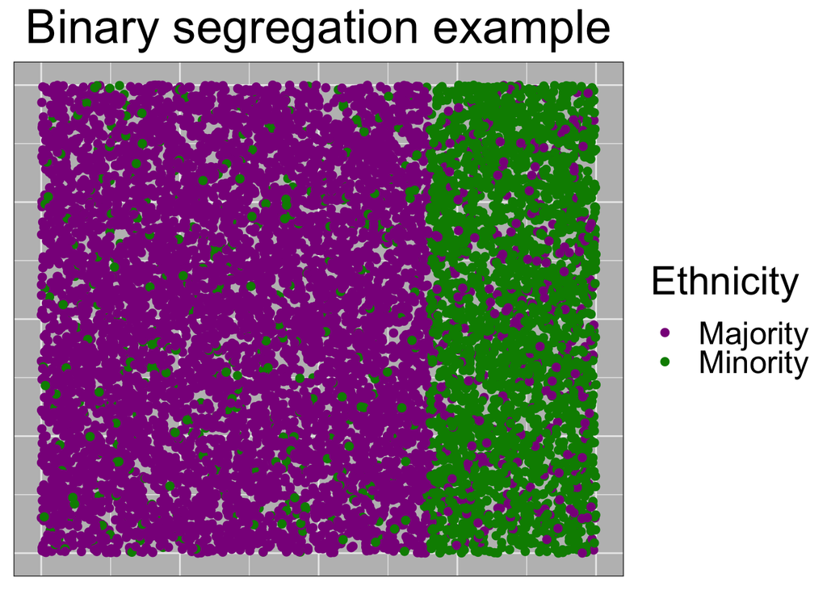

```r
#make one and plot
d = create_Seg(n = 10000, xlim = 100, ylim = 100, pminority = 0.3, conc = 0.8) %>% rename(Ethnicity = minor) %>%
  mutate(Ethnicity = mapvalues(Ethnicity, from = c('TRUE', 'FALSE'), to = c('Minority','Majority')))

ggplot(data = d) + geom_point(aes(x = long, y = lat, color = Ethnicity), size = 2) + theme_bw() +
  ggtitle('Binary segregation example') + theme(text = element_text(size=24), plot.title = element_text(hjust = 0.5)) +
  scale_shape_manual(values = c(1, 2)) +
  theme(axis.title.x=element_blank(),
        axis.text.x=element_blank(),
        axis.ticks.x=element_blank(),
        axis.title.y=element_blank(),
        axis.text.y=element_blank(),
        axis.ticks.y=element_blank(),
        panel.background = element_rect(fill = "grey")) +
  scale_color_manual(values=c("darkmagenta", "green4")) +
  xlim(0,100) + ylim(0,100)
```

```r
path0 = paste0('/Users/jeremyspater/Dropbox/duke/political economy core/prospectus/methods paper/results_output/',Sys.Date(),'/')
dir.create(path0)
#ggsave(filename = paste0(path0, 'binary_seg_example_website.png'), height = 200, width = 200, units = 'mm'); rm(path0)
```

### Cluster DGP

In neighborhoods generated using the cluster DGP, individuals are located in circular clusters that are situated randomly throughout the neighborhood. In segregated cluster neighborhoods, each cluster is predominantly made up of individuals from one group or the other (majority or minority).

The cluster DGP generates circular clusters of individuals within the neighborhood. For segregated neighborhoods, each cluster consists predominantly of individuals from one group, while for integrated neighborhoods, clusters are not segregated by group.

```r
####################################################################################################
#Clustered process

library(spatstat)

#https://rdrr.io/cran/spatstat/man/rPoissonCluster.html
# multitype Neyman-Scott process (each cluster is a multitype process)
#[This is same as Matern cluster process, only with marks?]
nclust2 <- function(x0, y0, radius, n, types=c("yes", "no"), p) {
  X <- runifdisc(n, radius, centre=c(x0, y0))
  #M <- sample(types, n, replace=TRUE, prob = c(p, 1-p)) #this just makes the marks random
  M <- sample(types, 1, replace=TRUE, prob = c(p, 1-p)) %>% rep(n)#this gives everybody in the cluster the same mark
  marks(X) <- M
  return(X)
}

#Nonsegregated version: Type is NOT by cluster
nclust1 <- function(x0, y0, radius, n) {
  X <- runifdisc(n, radius, centre=c(x0, y0))
  return(X)
}

ClusterSeg = function(n_samp = 100, p = 0.3, nclus = 13, ka = 0.05, r = 3){
  kids = rPoissonCluster(kappa = ka, #determines number of clusters
                         expand = 10, #expansion window for parents (so cluster center can be offscreen)
                         rcluster = nclust2, #function for generating clusters, above
                         radius = r,#3, #tried 10, but the clusters overlap too much. Size of cluster
                         n = nclus, #tried 5, but it didn't look very segregated. Number in cluster
                         p = p, #prob of minority
                         win = owin(c(0,100),c(0,100))) #limits of window

  kids_df = data.frame(long = kids$x,
                       lat = kids$y,
                       minor = kids$marks)
  ns = min(nrow(kids_df), n_samp)
  return(kids_df[sample(nrow(kids_df), ns), ]) #return sample of n rows
}

ClusterNonSeg = function(n_samp = 100, p = 0.3, nclus = 13, ka = 0.05, r = 3){
  kids = rPoissonCluster(kappa = ka, #determines number of clusters
                         expand = 10, #expansion window for parents (so cluster center can be offscreen)
                         rcluster = nclust1, #function for generating clusters, above
                         radius = r,#3, Size of cluster
                         n = nclus, #Number in cluster
                         #p = p,
                         win = owin(c(0,100),c(0,100))) #limits of window

  marks(kids) = sample( c('yes', 'no'), kids$n, replace=TRUE, prob = c(p, 1-p)) #select marks; not by cluster (because nonseg). Determines majority/minority

  kids_df = data.frame(long = kids$x,
                       lat = kids$y,
                       minor = kids$marks)
  ns = min(nrow(kids_df), n_samp)
  return(kids_df[sample(nrow(kids_df), ns), ]) #return sample of n rows
}
```

This code creates a cluster-segregated neighborhood and makes a plot.

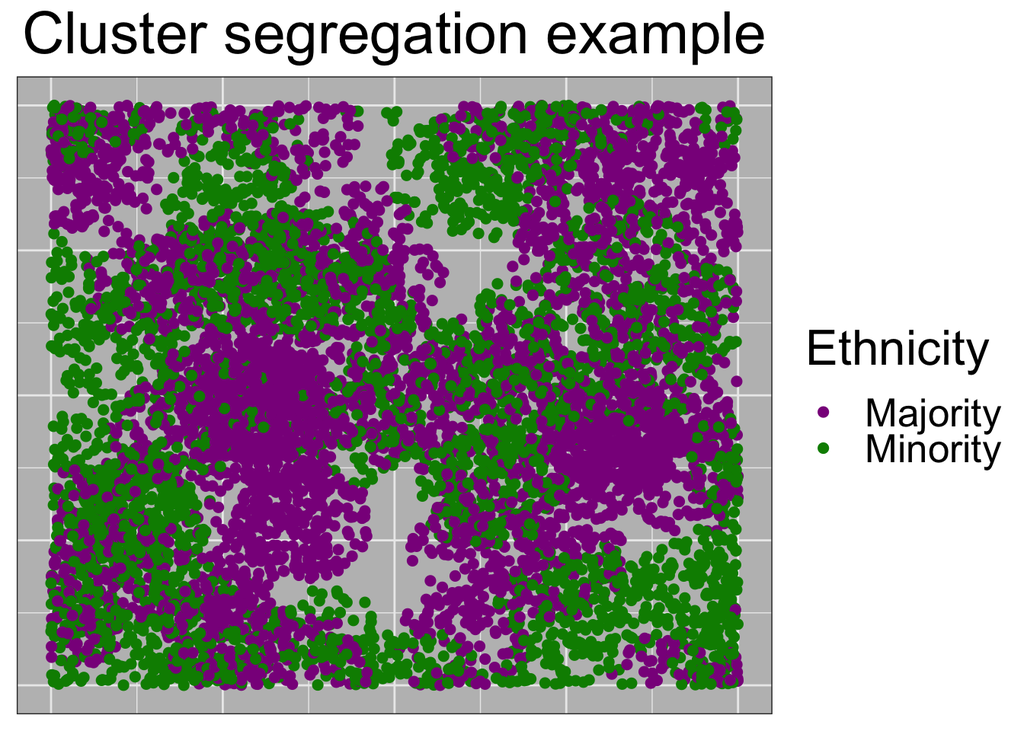

```r
#make one and plot
d = ClusterSeg(ka = 0.01, nclus = 100, r = 10, p = 0.4, n_samp = 1E6) %>% rename(Ethnicity = minor) %>%
  mutate(Ethnicity = mapvalues(Ethnicity, from = c('yes', 'no'), to = c('Minority','Majority')))

#ggplot(data = d) + geom_point(aes(x = long, y = lat, shape = Ethnicity), size = 2) + theme_bw() +
ggplot(data = d) + geom_point(aes(x = long, y = lat, color = Ethnicity), size = 2) + theme_bw() +
  ggtitle('Cluster segregation example') +
  theme(text = element_text(size=24), plot.title = element_text(hjust = 0.5)) +
  scale_shape_manual(values = c(1, 2)) +
  theme(axis.title.x=element_blank(),
        axis.text.x=element_blank(),
        axis.ticks.x=element_blank(),
        axis.title.y=element_blank(),
        axis.text.y=element_blank(),
        axis.ticks.y=element_blank(),
        panel.background = element_rect(fill = "grey")) +
  scale_color_manual(values=c("darkmagenta", "green4")) +
  xlim(0,100) + ylim(0,100)
```

```r
path0 = paste0('/Users/jeremyspater/Dropbox/duke/political economy core/prospectus/methods paper/results_output/',Sys.Date(),'/')
dir.create(path0)
#ggsave(filename = paste0(path0, 'cluster_seg_example_website.png'), height = 200, width = 200, units = 'mm'); rm(path0)
```

## Segregation Classification

We would like to classify neighborhoods as segregated or nonsegregated. To do this, we will first calculate the k-nearest-neighbors (KNN), defined here for a household, as the number of the closest households that are the same ethnicity as the household in question. For example, if k = 5, and 4 of the 5 households that are closest to us are of the same ethnicity as us, then our KNN is 4.

First, we define functions to create simulated neighborhoods (segregated and nonsegregated) and calculate their KNN. We will do this for 2000 neighborhoods (half segregated, half nonsegregated or integrated), and output the time elapsed (the code is rather slow as written; it could be vectorized for better performance).

```r
#code from 4-7-20 Moments copy

####################################################################################################
#Functions to calculate segregation

#May 2019 code to define K-nearest
source("https://raw.githubusercontent.com/jeremyspater/knn_moments/main/5-10-19_sim_knearest_gh.R")
# ####################################################################################################

#Functions to calculate k-nearest mean, median, and sd for large number of simulations (BINARY)
set.seed(1234)
#For nonsegregated neighborhoods
K_Nonseg_M = function(NeighSize, pminority = 0.3, k_in = 10){ #new version 4-1-20; higher moments
  A = create_Nonseg(n = NeighSize,
                    xlim = xlim,
                    ylim = ylim,
                    pminority = pminority)
  A_prime = k_sim(A, k = k_in)
  #out = c( mean( A_prime[, paste0('Nearest_', k_in, '_Same') ] ) )
  out = data.frame(KNearest_Mean = mean( A_prime[, paste0('Nearest_', k_in, '_Same') ] ),
                   KNearest_SD = sd( A_prime[, paste0('Nearest_', k_in, '_Same') ] ),
                   KNearest_Var = var( A_prime[, paste0('Nearest_', k_in, '_Same') ] ),
                   KNearest_Skew = skewness( A_prime[, paste0('Nearest_', k_in, '_Same') ] ),
                   KNearest_Kur = kurtosis( A_prime[, paste0('Nearest_', k_in, '_Same') ] ))
  return(out)
}

#For segregated neighborhoods
K_Seg_M = function(NeighSize, pminority = 0.3, k_in = 10,  conc = 0.7){
  A = create_Seg(n = NeighSize,
                 xlim = xlim,
                 ylim = ylim,
                 pminority = pminority,
                 conc = conc)
  A_prime = k_sim(A, k = k_in)
  #out = c( mean( A_prime[, paste0('Nearest_', k_in, '_Same') ] ) )
  out = data.frame(KNearest_Mean = mean( A_prime[, paste0('Nearest_', k_in, '_Same') ] ),
                   KNearest_SD = sd( A_prime[, paste0('Nearest_', k_in, '_Same') ] ),
                   KNearest_Var = var( A_prime[, paste0('Nearest_', k_in, '_Same') ] ),
                   KNearest_Skew = skewness( A_prime[, paste0('Nearest_', k_in, '_Same') ] ),
                   KNearest_Kur = kurtosis( A_prime[, paste0('Nearest_', k_in, '_Same') ] ))
  return(out)
}

#Obtain KNN statistics for parameter grid, seg and nonseg (BINARY)
#pminority_vec =  seq(0.1, 0.5, 0.1) #proportion of minorities
#conc_vec = seq(0.5, 1, 0.1) #concentration
pminority_vec = c(0.25) #just one value
conc_vec = c(0.75) #just one value

parm_exp = expand.grid(pminority_vec, conc_vec) %>%
  rename(p_minority = Var1,
         conc = Var2) ; rm(pminority_vec, conc_vec) #

#Run on grid
nsim = 1000#1000 #
n_neigh = 100#100 #people per neighborhood
n_tot = nrow(parm_exp) * nsim #number of rows in results matrix: grid points * sims/point
results_mat_nonseg = data.frame(matrix(NA, nrow = n_tot, ncol = 8))
results_mat_seg = data.frame(matrix(NA, nrow = n_tot, ncol = 8))
names(results_mat_nonseg) = c('NeighType','PMinor_Parm','Conc_Parm','KNearest_Mean', 'KNearest_SD', 'KNearest_Var', 'KNearest_Skew', 'KNearest_Kur')
names(results_mat_seg) = c('NeighType','PMinor_Parm','Conc_Parm','KNearest_Mean', 'KNearest_SD', 'KNearest_Var', 'KNearest_Skew', 'KNearest_Kur')
tic()
for(j in 1:nrow(parm_exp)){
  #print(j)
  #K-nearest
  Out_K_Nonseg = ldply(1:nsim, function(x) K_Nonseg_M(NeighSize = n_neigh,
                                                    pminority = parm_exp$p_minority[j],
                                                    k_in = 10 ))
  Out_K_Seg = ldply(1:nsim, function(x) K_Seg_M(NeighSize = n_neigh,
                                              pminority = parm_exp$p_minority[j],
                                              k_in = 10,
                                              conc = parm_exp$conc[j] ))
  c1 = (j-1)*nsim + 1
  c2 = (j)*nsim
  results_mat_nonseg[c1:c2,1] = 'Nonseg. Binary'; results_mat_nonseg[c1:c2,2] = parm_exp[j,1]; results_mat_nonseg[c1:c2,3] = parm_exp[j,2]
  results_mat_nonseg[c1:c2,4:8] =  Out_K_Nonseg    #Nonseg Results
  results_mat_seg[c1:c2,1] = 'Seg. Binary'; results_mat_seg[c1:c2,2] = parm_exp[j,1]; results_mat_seg[c1:c2,3] = parm_exp[j,2]
  results_mat_seg[c1:c2,4:8] = Out_K_Seg    #Seg results
}
toc() #8 sec for 10 simulations with 30 rows of parm_exp. 700 sec for 1000 simulations
```

```
## 7.319 sec elapsed
```

```r
#8 sec for 1000 simulations with 1 row of parm_exp
```

Now we will use the moments of the KNN metric to classify whether neighborhoods are segregated or integrated. In the step above, we created 2000 neighborhoods (half segregated, half integrated). We will used the first 1900 rows for supervised Naive Bayes classification, and the remaining 100 neighborhoods as a test set.

The number that the script prints at the end is the number out of 100 neighborhoods in the test set that were classified correctly. In testing, this was about 95%: Not bad!

```r
results_mat_seg$Outcome = 1 #set outcome variable to 1 for segregated neighborhoods
results_mat_nonseg$Outcome = 0 #set outcome variable to 0 for non-segregated neighborhoods

data = rbind(results_mat_seg, results_mat_nonseg) #put seg, nonseg results together. 2k rows
data$Outcome = as.factor(data$Outcome)

#Naive Bayes

#model <- naiveBayes(Outcome ~ KNearest_Mean, data = data)
#pred = predict(model, newdata = data) #predictions for full data set

#try this again on test, training data
model <- naiveBayes(Outcome ~ KNearest_Mean, data = data[1:(nrow(data)-101),]) #save last 100 for test
pred = predict(model, newdata = data[(nrow(data)-100):nrow(data),]) #test on last 100
sum(pred == data$Outcome[(nrow(data)-100):nrow(data)]) #95%! Not half bad
```

```
## [1] 97
```